# Lab 04 - Covid Wrangling

Covid-19 case counts frequently make headlines these days, but the actual data is notoriously difficult to work with. The main problems are statistical: testing is extremely biased, so most case counts are substantial *under*estimates. But even if we assume that reported counts are somehow useful, there are problems that come up in analyzing and modeling them that are well suited to the tools that we are studying this week.

In this lab we will work with Covid-19 case count data from one of the most prominent sources, the Systems group at Johns Hopkins ([CSEE](https://systems.jhu.edu/)). In the process of making a few simple plots with this data, we will face and solve several important data wrangling challenges.

The learning goals of this lab are:

- Recognize some of the issues that come up in real-world data and apply common approaches to resolving them
- Manipulate and transform data to prepare it for visualization.
- Start to work together in teams.

## Getting started

Go to [our GitHub org](https://github.com/Calvin-DS202-FA20/) and find your team’s `lab04` repo.

Each person on the team should clone the repo and try to knit the template `Rmd`, as usual.

## Warm up

**Pick one team member to complete the steps in this section while the others contribute to the discussion but do not actually touch the files on their computer.**

Before we dive into the data, let’s warm up with some simple exercises.

### Metadata

- Open the R Markdown (Rmd) file in your project, change the author name to your **team** name, and knit the document.
- Knit, commit, push.

### Pulling changes

Now, the remaining team members who have not been concurrently making these changes on their projects should click on the **Pull** button in their Git pane and observe that the changes are now reflected on their projects as well.

## Get the data

As you might imagine, keeping a comprehensive list of all COVID-19 cases worldwide involves pulling data from numerous sources (and frequent updating). Fortunately, some folks at Johns Hopkins have been doing that work and putting the resulting data into a github repository that anyone can access.

### Navigating the GitHub Repo

You can visit their GitHub project at https://github.com/CSSEGISandData/COVID-19. There you will find

- details about what sources were used for the data,
- what sorts of data are available, and
- some places the data have been used

You will also see this note:

> The Website relies upon publicly available data from multiple sources, that do not always agree.

### Finding some data

You could clone the repository, but you also just pull the data directly from their repository. They’ve split the data into “daily reports” (one CSV per day, all measures) and “time series” (one CSV per measure, all days). Here is an example page showing [one of the data sets](https://raw.githubusercontent.com/CSSEGISandData/COVID-19/master/csse_covid_19_data/csse_covid_19_time_series/time_series_covid19_confirmed_global.csv) available to you.

[figure not shown]

### We want raw data

GitHub renders CSVs in a fancy way, but you can get the plain old CSV if you click the Raw button. We’re mostly interested in the URL for this file, since that will let us pull the data into R.

We split the URL into multiple lines so it’s easier to read it.

```r
confirmed_global_url <- paste0(
  "https://raw.githubusercontent.com/CSSEGISandData/COVID-19/master/",
  "csse_covid_19_data/csse_covid_19_time_series/time_series_covid19_",
  "confirmed", # also: "deaths", "recovered"
  "_global.csv"
)
```

Read it in.

```r
confirmed_global <- confirmed_global_url %>%
  pins::pin() %>%   # Make or update a local cached copy. Comment this line out if you want.
  read_csv(col_types = cols(
    .default = col_double(),
    `Province/State` = col_character(),
    `Country/Region` = col_character()
  )) %>%
  rename(
    country_or_region = `Country/Region`,
    province_or_state = `Province/State`
  )
```

Let’s have a look.

```r
reactable::reactable(confirmed_global, searchable = TRUE)
```

| province_or_state | country_or_region | Lat | Long | 1/22/20 | 1/23/20 | 1/24/20 | 1/25/20 | 1/26/20 | 1/27/20 | 1/28/20 | 1/29/20 | 1/30/20 | 1/31/20 | 2/1/20 | 2/2/20 | 2/3/20 | 2/4/20 | 2/5/20 | 2/6/20 | 2/7/20 | 2/8/20 | 2/9/20 | 2/10/20 | 2/11/20 | 2/12/20 | 2/13/20 | 2/14/20 | 2/15/20 | 2/16/20 | … |
| --- | --- | --- | --- | --- | --- | --- | --- | --- | --- | --- | --- | --- | --- | --- | --- | --- | --- | --- | --- | --- | --- | --- | --- | --- | --- | --- | --- | --- | --- | --- |
| NA | Afghanistan | 33.93911 | 67.709953 | 0 | 0 | 0 | 0 | 0 | 0 | 0 | 0 | 0 | 0 | 0 | 0 | 0 | 0 | 0 | 0 | 0 | 0 | 0 | 0 | 0 | 0 | 0 | 0 | 0 | 0 | … |
| NA | Albania | 41.1533 | 20.1683 | 0 | 0 | 0 | 0 | 0 | 0 | 0 | 0 | 0 | 0 | 0 | 0 | 0 | 0 | 0 | 0 | 0 | 0 | 0 | 0 | 0 | 0 | 0 | 0 | 0 | 0 | … |
| NA | Algeria | 28.0339 | 1.6596 | 0 | 0 | 0 | 0 | 0 | 0 | 0 | 0 | 0 | 0 | 0 | 0 | 0 | 0 | 0 | 0 | 0 | 0 | 0 | 0 | 0 | 0 | 0 | 0 | 0 | 0 | … |
| NA | Andorra | 42.5063 | 1.5218 | 0 | 0 | 0 | 0 | 0 | 0 | 0 | 0 | 0 | 0 | 0 | 0 | 0 | 0 | 0 | 0 | 0 | 0 | 0 | 0 | 0 | 0 | 0 | 0 | 0 | 0 | … |
| NA | Angola | -11.2027 | 17.8739 | 0 | 0 | 0 | 0 | 0 | 0 | 0 | 0 | 0 | 0 | 0 | 0 | 0 | 0 | 0 | 0 | 0 | 0 | 0 | 0 | 0 | 0 | 0 | 0 | 0 | 0 | … |
| NA | Antigua and Barbuda | 17.0608 | -61.7964 | 0 | 0 | 0 | 0 | 0 | 0 | 0 | 0 | 0 | 0 | 0 | 0 | 0 | 0 | 0 | 0 | 0 | 0 | 0 | 0 | 0 | 0 | 0 | 0 | 0 | 0 | … |
| NA | Argentina | -38.4161 | -63.6167 | 0 | 0 | 0 | 0 | 0 | 0 | 0 | 0 | 0 | 0 | 0 | 0 | 0 | 0 | 0 | 0 | 0 | 0 | 0 | 0 | 0 | 0 | 0 | 0 | 0 | 0 | … |
| NA | Armenia | 40.0691 | 45.0382 | 0 | 0 | 0 | 0 | 0 | 0 | 0 | 0 | 0 | 0 | 0 | 0 | 0 | 0 | 0 | 0 | 0 | 0 | 0 | 0 | 0 | 0 | 0 | 0 | 0 | 0 | … |
| Australian Capital Territory | Australia | -35.4735 | 149.0124 | 0 | 0 | 0 | 0 | 0 | 0 | 0 | 0 | 0 | 0 | 0 | 0 | 0 | 0 | 0 | 0 | 0 | 0 | 0 | 0 | 0 | 0 | 0 | 0 | 0 | 0 | … |
| New South Wales | Australia | -33.8688 | 151.2093 | 0 | 0 | 0 | 0 | 3 | 4 | 4 | 4 | 4 | 4 | 4 | 4 | 4 | 4 | 4 | 4 | 4 | 4 | 4 | 4 | 4 | 4 | 4 | 4 | 4 | 4 | … |

[output cut: 256 more lines]

Here are all of the unique country names in the dataset, for future reference:

```r
unique(confirmed_global$country_or_region) %>% paste(collapse = ", ")
```

```
## [1] "Afghanistan, Albania, Algeria, Andorra, Angola, Antigua and Barbuda, Argentina, Armenia, Australia, Austria, Azerbaijan, Bahamas, Bahrain, Bangladesh, Barbados, Belarus, Belgium, Belize, Benin, Bhutan, Bolivia, Bosnia and Herzegovina, Botswana, Brazil, Brunei, Bulgaria, Burkina Faso, Burma, …
```

## Tidy data

1. Make a *tidy* data frame with this data. Each row should be a case count for a country on a particular day. All columns should have the correct data type.

You will need the `pivot_longer` function from `tidyr` and the `parse_date_time` function from `lubridate`.

**Switch who’s committing here.** Current person needs to Commit and Push, everyone else Pull.

## Plotting

2. Plot the total number of confirmed cases worldwide by date.

For nice *x*-axis labels, add `scale_x_datetime(date_breaks = "1 month", date_labels = "%b")` to the plot.

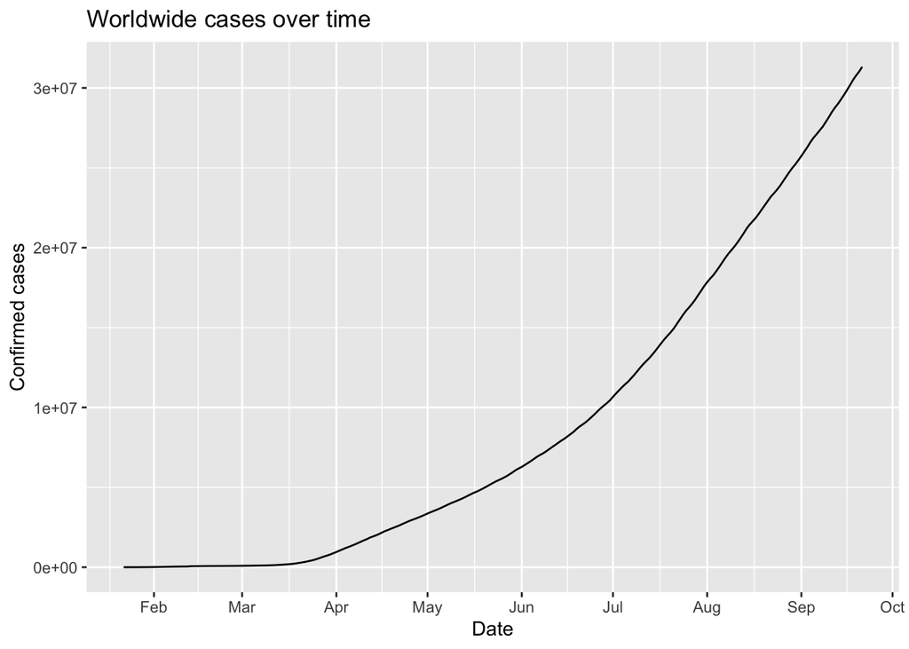

You may need to search the data table to find the country names.

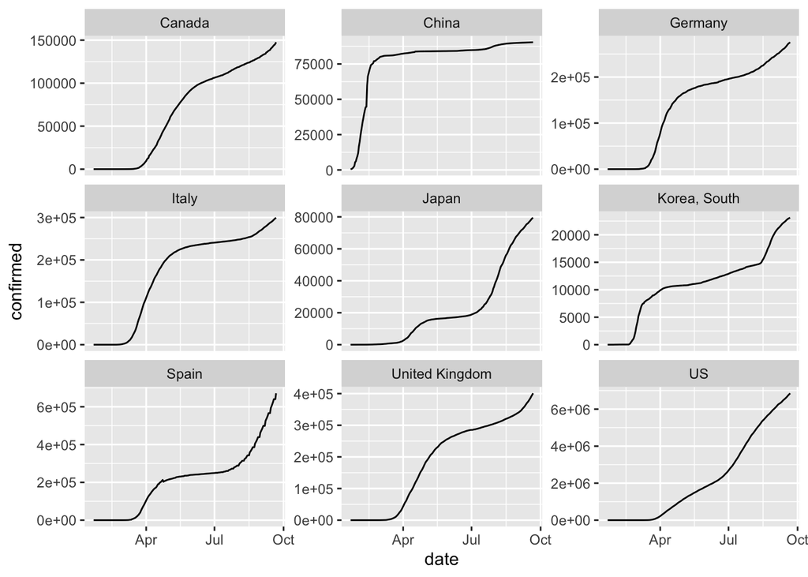

## Per Capita

Per-capita case counts would allow us to compare across countries in a different way. But we’ll need population data.

Here is some code to get some data. We’ve already run the first one for you, so all you need to do is run the second one (which is already in your repo).

```r
pop_data_filename <- "data/worldbank_sp_pop_totl.csv"
if (!file.exists(pop_data_filename)) {
  wbstats::wb_data(
    "SP.POP.TOTL",
    mrnev = 1    # this stands for: "most recent non-empty value"
  ) %>%
    write_csv(pop_data_filename)
}
```

```r
pop_data_filename <- "data/worldbank_sp_pop_totl.csv"
population <-
  read_csv(
    pop_data_filename,
    col_types = cols_only(
      iso2c = col_character(),
      iso3c = col_character(),
      country = col_character(),
      date = col_double(),
      SP.POP.TOTL = col_double(),
      footnote = col_character()
    )
  ) %>%
  select(iso2c, iso3c, country, population = SP.POP.TOTL)
```

4. Plot number of cases per capita for the same countries as you chose above.

## Appendix

This exercise was adapted from one that Randall Pruim and Kenneth Arnold constructed for DATA 303 in Spring 2020. The team Git coaching is adapted from https://datasciencebox.org.